# Module 3

STAT 6021

Taylor R. Brown, PhD

# Multiple Linear Regression

More predictors!

$$y = \beta_0 + \beta_1 x_1 + \beta_2x_2 + \cdots + \beta_k x_k + \epsilon$$

tip: don’t say “multivariate”

# Multiple Linear Regression

$$E[y] = \beta_0 + \beta_1 x_1 + \beta_2x_2 + \cdots + \beta_k x_k$$

- $\frac{dE[y]}{dx_3} = \beta_3$
- one unit change in $x_3$
- assumes all other regressors aren’t changing
- disregards noise

These are *very* flexible…

# Multiple Linear Regression

Special case example: polynomial regression

$$y = \beta_0 + \beta_1 x + \beta_2 x^2 + \beta_3 x^3 + \epsilon$$

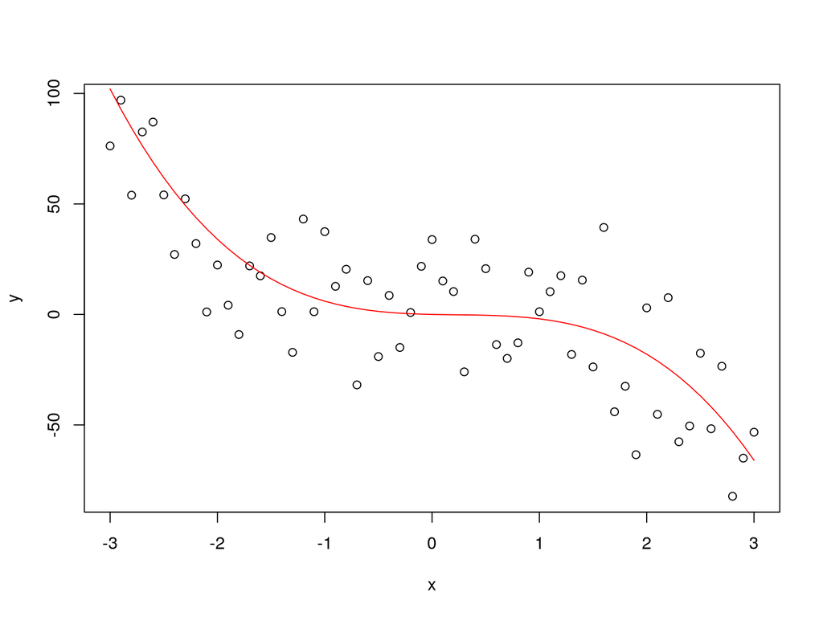

```r
betas <- c(-1,2,-3)
x <- seq(-3,3,.1)
y_line <- cbind(x,x^2,x^3) %*% betas
y <- y_line +  rnorm(n = length(x), sd = 20)
plot(x,y)
points(x,y_line, col="red", type = "l")
```

# Multiple Linear Regression

Special case example: interaction effects
$$y = \beta_0 + \beta_1 x_1 + \beta_2 x_2 + \beta_3 x_1x_2 + \epsilon$$
with $(\beta_0, \beta_1, \beta_2, \beta_3) = (-2, 3, -.2, -4)$

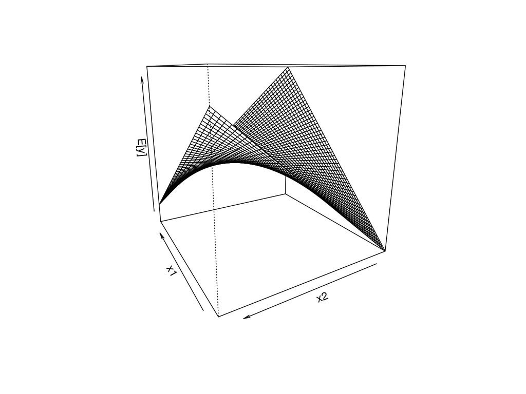

# Multiple Linear Regression

Special case example: second-order model with interactions

$$y = \beta_0 + \beta_1 x_1 + \beta_2 x_2 + \beta_3 x_1^2 + \beta_4 x_2^2 + \beta_5x_1x_2 + \epsilon$$
with $(\beta_0, \beta_1, \beta_2, \beta_3, \beta_4, \beta_5) = (800, 10, 7, 8.5, -5, 4)$

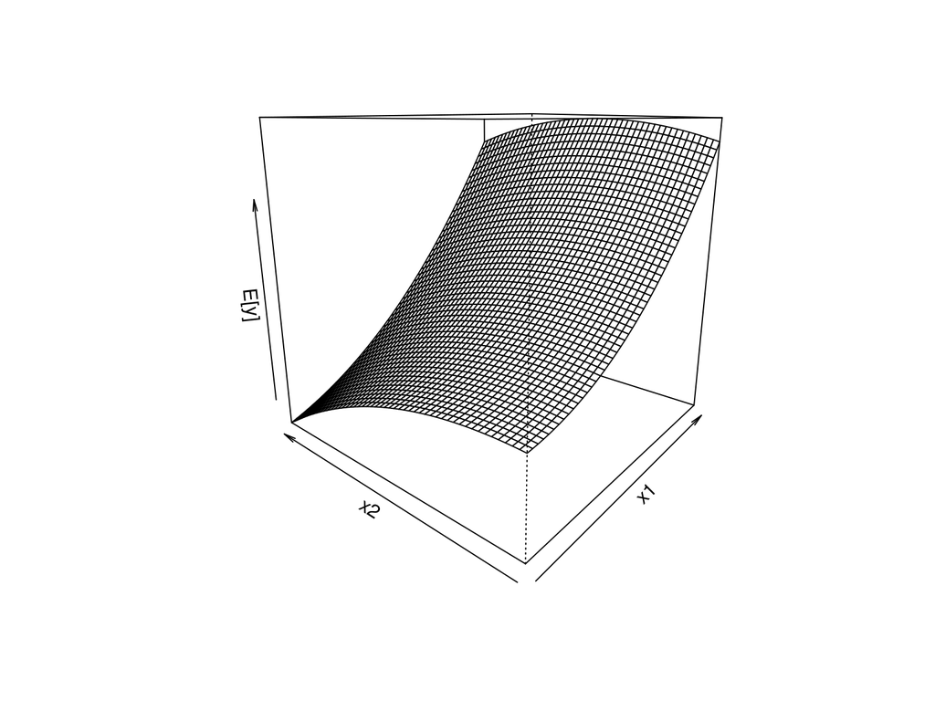

# Estimating the coefficients

To estimate the coefficients , we again look at the loss
$$S(\beta_0, \beta_1, \ldots, \beta_k) = \sum_{i=1}^n(y_i - [\beta_0 + \beta_1 x_{i1} + \beta_2 x_{i2} + \cdots + \beta_k x_{ik}])^2$$
We take derivatives with respect to all betas, and set them all equal to $0$, and then solve the system of equations…

# Matrices to the rescue

It’s cleaner if we use matrices

$$\mathbf{y} = \mathbf{X} \boldsymbol{\beta} + \boldsymbol{\epsilon}$$

$$\mathbf{y}
=
\begin{bmatrix}
y_1 \\
\vdots \\
y_n
\end{bmatrix}
\hspace{10mm}
\mathbf{X}
=
\begin{bmatrix}
1 & x_{11} & \cdots & x_{1k} \\
1 & x_{21} & \cdots & x_{2k}\\
\vdots & \vdots & & \vdots \\
1 & x_{n1} & \cdots & x_{nk}
\end{bmatrix}
=
\begin{bmatrix}
\mathbf{x}_1^{\intercal} \\
\mathbf{x}_2^{\intercal}\\
\vdots \\
\mathbf{x}_n^{\intercal}
\end{bmatrix}$$

$$\boldsymbol{\beta}
=
\begin{bmatrix}
\beta_0 \\
\beta_1 \\
\vdots \\
\beta_k
\end{bmatrix}
\hspace{10mm}
\boldsymbol{\epsilon}
=
\begin{bmatrix}
\epsilon_1 \\
\epsilon_2\\
\vdots\\
\epsilon_{n}
\end{bmatrix}$$

# Matrices to the rescue

rewriting the loss

$$\begin{align*}
S(\beta_0, \beta_1, \ldots, \beta_k) &= S(\boldsymbol{\beta})\\
&= \sum_{i=1}^n(y_i - [\beta_0 + \beta_1 x_1 + \beta_2x_2 + \cdots + \beta_k x_k])^2 \\
&= \sum_{i=1}^n(y_i - \mathbf{x}_i^{\intercal}\boldsymbol{\beta} )^2 \\
&= (\mathbf{y} - \mathbf{X} \boldsymbol{\beta})^{\intercal}(\mathbf{y} - \mathbf{X} \boldsymbol{\beta})
\end{align*}$$

Warning: you have to equivocate on $\boldsymbol{\beta}$ or $\boldsymbol{\epsilon}$. The book has chosen the second option; however, we always use $\epsilon$ to refer to true, unobserved random errors, not residuals. Instead, when we write the loss, we are not thinking of $\boldsymbol{\beta}$ as the true coefficient vector; instead, we think of it as some input vector for this score function.

# Matrices to the rescue

A few more moves

$$\begin{align*}
S(\boldsymbol{\beta}) &= (\mathbf{y} - \mathbf{X} \boldsymbol{\beta})^{\intercal}(\mathbf{y} - \mathbf{X} \boldsymbol{\beta}) \\
&= (\mathbf{y}^{\intercal} - [\mathbf{X} \boldsymbol{\beta}]^{\intercal})(\mathbf{y} - \mathbf{X} \boldsymbol{\beta}) \\
&=(\mathbf{y}^{\intercal} - \boldsymbol{\beta}^{\intercal} \mathbf{X}^{\intercal} )(\mathbf{y} - \mathbf{X} \boldsymbol{\beta}) \\
&= \mathbf{y}^{\intercal}\mathbf{y} - \mathbf{y}^{\intercal}\mathbf{X} \boldsymbol{\beta} \\
&\hspace{10mm} - \boldsymbol{\beta}^{\intercal} \mathbf{X}^{\intercal} \mathbf{y} + \boldsymbol{\beta}^{\intercal} \mathbf{X}^{\intercal}\mathbf{X} \boldsymbol{\beta} \\
&= \mathbf{y}^{\intercal}\mathbf{y} - 2\mathbf{y}^{\intercal}\mathbf{X} \boldsymbol{\beta} + \boldsymbol{\beta}^{\intercal} \mathbf{X}^{\intercal}\mathbf{X} \boldsymbol{\beta}
\end{align*}$$

# Matrices to the rescue

taking the derivatives of the loss $S(\boldsymbol{\beta}) = \mathbf{y}^{\intercal}\mathbf{y} - 2\mathbf{y}^{\intercal}\mathbf{X} \boldsymbol{\beta} + \boldsymbol{\beta}^{\intercal} \mathbf{X}^{\intercal}\mathbf{X} \boldsymbol{\beta}$

$$\frac{\partial S}{\partial\boldsymbol{\beta} } = -2\mathbf{X}^{\intercal} \mathbf{y} + 2\mathbf{X}^{\intercal}\mathbf{X}\boldsymbol{\beta} \overset{\text{set}}{=} 0$$
rearranging yields the *normal* equations
$$(\mathbf{X}^{\intercal}\mathbf{X})\boldsymbol{\hat{\beta}} = \mathbf{X}^{\intercal} \mathbf{y}$$
and solving for the coefficient vector finally gives us
$$\boldsymbol{\hat{\beta}} = (\mathbf{X}^{\intercal}\mathbf{X})^{-1}\mathbf{X}^{\intercal} \mathbf{y}$$
multiplying both sides by the design matrix gives us the predictions
$$\hat{\mathbf{y}} \overset{\text{def}}{=} \mathbf{X}\boldsymbol{\hat{\beta}} = \mathbf{X}(\mathbf{X}^{\intercal}\mathbf{X})^{-1}\mathbf{X}^{\intercal} \mathbf{y}$$

# The hat matrix

$$\hat{\mathbf{y}} \overset{\text{def}}{=} \mathbf{X}\boldsymbol{\hat{\beta}} = \mathbf{X}(\mathbf{X}^{\intercal}\mathbf{X})^{-1}\mathbf{X}^{\intercal} \mathbf{y}$$

The matrix
$$\mathbf{H} = \mathbf{X}(\mathbf{X}^{\intercal}\mathbf{X})^{-1}\mathbf{X}^{\intercal}$$
is special. It is called the *hat matrix* or *projection matrix*.

# The residuals

$$\hat{\mathbf{y}} \overset{\text{def}}{=} \mathbf{X}\boldsymbol{\hat{\beta}} = \mathbf{X}(\mathbf{X}^{\intercal}\mathbf{X})^{-1}\mathbf{X}^{\intercal} \mathbf{y}$$

We’ll use these quite often

$$\mathbf{e} = \mathbf{y} - \hat{\mathbf{y}} =(\mathbf{I}_n - \mathbf{H}) \mathbf{y}$$

# Using `R`

What to do?

```
##           y   x
## 1 -520.2930 -10
## 2 -397.7454  -9
## 3 -298.1390  -8
## 4 -231.1284  -7
## 5 -144.6627  -6
## 6 -156.7459  -5
```

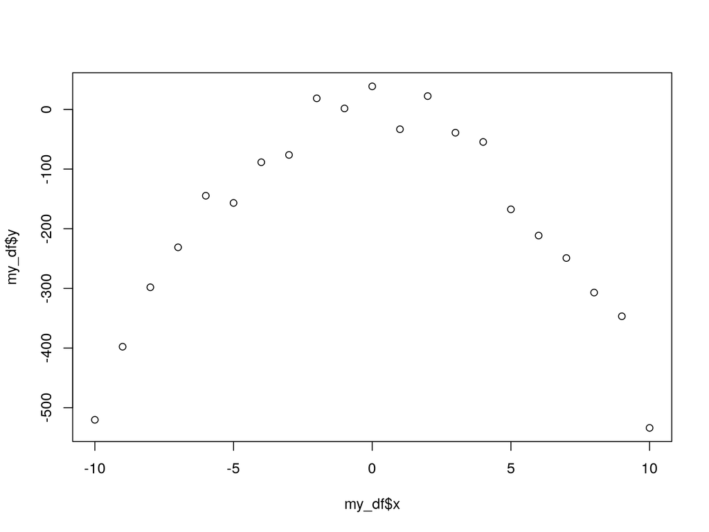

```r
plot(my_df$x, my_df$y)
```

# Using `R`

```r
my_df$xsquared <- x^2
mlr_model <- lm(y ~ x + xsquared, data=my_df)
summary(mlr_model)
```

```
##
## Call:
## lm(formula = y ~ x + xsquared, data = my_df)
##
## Residuals:
##     Min      1Q  Median      3Q     Max
## -46.172 -31.730   0.934  21.017  58.935
##
## Coefficients:
##             Estimate Std. Error t value Pr(>|t|)
## (Intercept)   6.1039    10.3340   0.591    0.562
## x            -0.1384     1.1356  -0.122    0.904
## xsquared     -5.0683     0.2104 -24.091 3.79e-15 ***
## ---
## Signif. codes:  0 '***' 0.001 '**' 0.01 '*' 0.05 '.' 0.1 ' ' 1
##
## Residual standard error: 31.51 on 18 degrees of freedom
## Multiple R-squared:  0.9699, Adjusted R-squared:  0.9666
## F-statistic: 290.2 on 2 and 18 DF,  p-value: 2.017e-14
```

# Using `R`

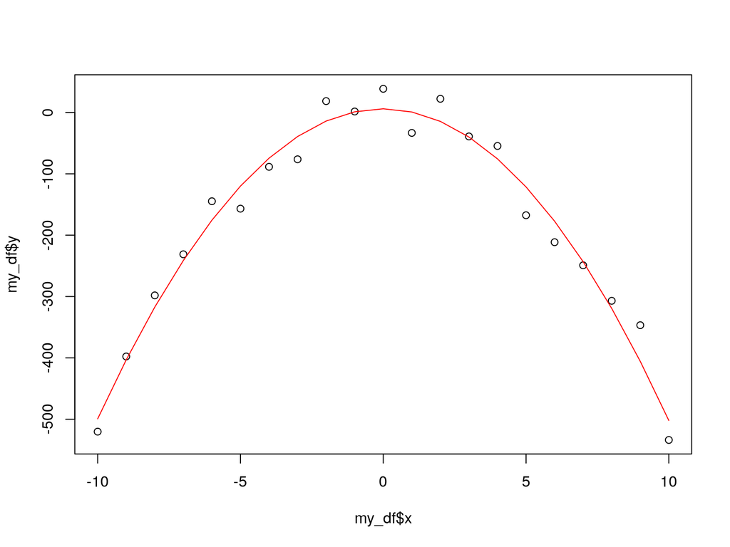

```r
fitted_vals <- predict(mlr_model)
plot(my_df$x, my_df$y)
points(my_df$x, fitted_vals, col = "red", type ="l")
```

# Back to the normal equations

$$(\mathbf{X}^{\intercal}\mathbf{X}) \boldsymbol{\hat{\beta}} = \mathbf{X}^{\intercal} \mathbf{y}$$
If $\mathbf{X} = \begin{bmatrix} \mathbf{1} & \mathbf{x}_1 & \cdots & \mathbf{x}_k \end{bmatrix}$
$$\begin{align*}
\mathbf{X}^{\intercal}\mathbf{X} &=
\begin{bmatrix}
\mathbf{1}^{\intercal} \\
\mathbf{x}_1^{\intercal} \\
\vdots \\
\mathbf{x}_k^{\intercal}
\end{bmatrix}
\begin{bmatrix} \mathbf{1} & \mathbf{x}_1 & \cdots & \mathbf{x}_k \end{bmatrix} \\
&=
\begin{bmatrix}
n & \sum_i x_{i1} & \sum_i x_{i2} & \cdots & \sum_i x_{ik} \\
\sum_i x_{i1} & \sum_i x_{i1}^2 & \sum_i x_{i1}x_{i2} & \cdots & \sum_i x_{i1}x_{ik} \\
\vdots & \vdots & \vdots & \ddots & \vdots\\
\sum_i x_{ik} & \sum_i x_{i1}x_{ik} & \sum_i x_{i2}x_{ik} & \cdots & \sum_i x_{ik}^2
\end{bmatrix}
\end{align*}$$

[a popular thread](https://stats.stackexchange.com/questions/22501/is-there-an-intuitive-interpretation-of-ata-for-a-data-matrix-a/22520#22520)

# Back to the normal equations

Rearranging the normal equations

$$(\mathbf{X}^{\intercal}\mathbf{X}) \boldsymbol{\hat{\beta}} = \mathbf{X}^{\intercal} \mathbf{y}$$
$$\mathbf{X}^{\intercal} \left( \mathbf{y} - \mathbf{X} \boldsymbol{\hat{\beta}}\right) = \mathbf{0}$$

can yield a geometrical interpretation. Choosing $\hat{\boldsymbol{\beta}}$ chooses the error to be orthogonal to the column space of the design matrix.

It’s easier to see if $n=3$ and $k=1$:

$$\begin{bmatrix}
\mathbf{1}_1^{\intercal} \left( \mathbf{y} - \mathbf{X} \boldsymbol{\hat{\beta}}\right)\\
\mathbf{x}_1^{\intercal}\left( \mathbf{y} - \mathbf{X} \boldsymbol{\hat{\beta}}\right)
\end{bmatrix}
=
\begin{bmatrix}
0\\
0
\end{bmatrix}$$

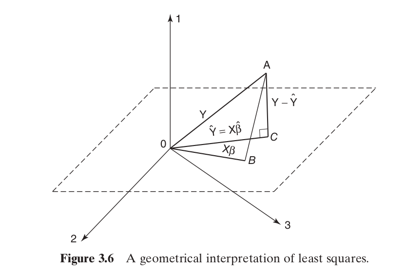

# Finding the distribution of $\hat{\boldsymbol{\beta}}$

$$\boldsymbol{\hat{\beta}} = (\mathbf{X}^{\intercal}\mathbf{X})^{-1}\mathbf{X}^{\intercal} \mathbf{y}$$
Taking its expectation is easy; just use linearity and the definition of $\mathbf{y}$.

Finding the variance is fun. Recall that property that for any fixed matrix $\mathbf{A}$ and random vector $\mathbf{W}$
$$V\left[\mathbf{A} \mathbf{W} \right] = \mathbf{A} V\left[ \mathbf{W} \right]\mathbf{A}^{\intercal}$$

This is analogous to the univariate case: $V[cX] = c^2V[X]$

# Finding the distribution of $\hat{\boldsymbol{\beta}}$

$$\begin{align*}
V\left[\boldsymbol{\hat{\beta}}\right]
&= V\left[(\mathbf{X}^{\intercal}\mathbf{X})^{-1}\mathbf{X}^{\intercal} \mathbf{y}\right] \\
&= \sigma^2 \left[(\mathbf{X}^{\intercal}\mathbf{X})^{-1}\mathbf{X}^{\intercal} \right]\left[(\mathbf{X}^{\intercal}\mathbf{X})^{-1}\mathbf{X}^{\intercal} \right]^{\intercal} \\
&= \sigma^2 (\mathbf{X}^{\intercal}\mathbf{X})^{-1}\mathbf{X}^{\intercal}\mathbf{X}(\mathbf{X}^{\intercal}\mathbf{X})^{-1} \\
&= \sigma^2 (\mathbf{X}^{\intercal} \mathbf{X})^{-1} \\
\end{align*}$$
when $V\left[\mathbf{y}\right] = \sigma^2 \mathbf{I}_n$

So
$$\boldsymbol{\hat{\beta}} \sim \text{Normal}\left( \boldsymbol{\beta}, \sigma^2(\mathbf{X}^{\intercal} \mathbf{X})^{-1} \right)$$

# estimating $\sigma^2$

We still estimate the error variance with the average squared residual:

$$\hat{\sigma}^2 = MS_{Res} = \frac{\sum_{i=1}^n (y_i- \hat{y}_i)^2 }{n-k-1}$$

Note we use $n-k -1$ instead of $n$. With simple linear regression $k=1$.

# estimating $\sigma^2$

It’s cleaner to write the sum of squares in terms of an inner product:

$$\hat{\sigma}^2 = MS_{Res} = \frac{(\mathbf{y} - \mathbf{X} \hat{\boldsymbol{\beta}})^{\intercal}(\mathbf{y} - \mathbf{X} \hat{\boldsymbol{\beta}})}{(n-k-1)}$$

The numerator is the loss function evaluated at $\hat{\boldsymbol{\beta}}$.

# using `R`

Here’s another way to get $\hat{\sigma}^2$

```r
anova(mlr_model)
```

```
## Analysis of Variance Table
##
## Response: y
##           Df Sum Sq Mean Sq  F value    Pr(>F)
## x          1     15      15   0.0149    0.9043
## xsquared   1 576253  576253 580.3548 3.794e-15 ***
## Residuals 18  17873     993
## ---
## Signif. codes:  0 '***' 0.001 '**' 0.01 '*' 0.05 '.' 0.1 ' ' 1
```

```r
names(anova(mlr_model))
```

```
## [1] "Df"      "Sum Sq"  "Mean Sq" "F value" "Pr(>F)"
```

```r
anova(mlr_model)$'Mean Sq'
```

```
## [1]     14.75595 576253.11609    992.93250
```

```r
anova(mlr_model)$'Mean Sq'[3]
```

```
## [1] 992.9325
```

# using `R`

Make your own function so you don’t have to re-write that code ever again!

```r
# define a function
getSSHat <- function(model_object){
  return(anova(model_object)$'Mean Sq'[3])
}
# use/call the function on a specific model
getSSHat(mlr_model)
```

```
## [1] 992.9325
```

# Scatterplots fail in MLR

Simulate data from
$$y = 8 - 5x_1 + 12x_2 + \epsilon$$
and look at the misleading scatterplots

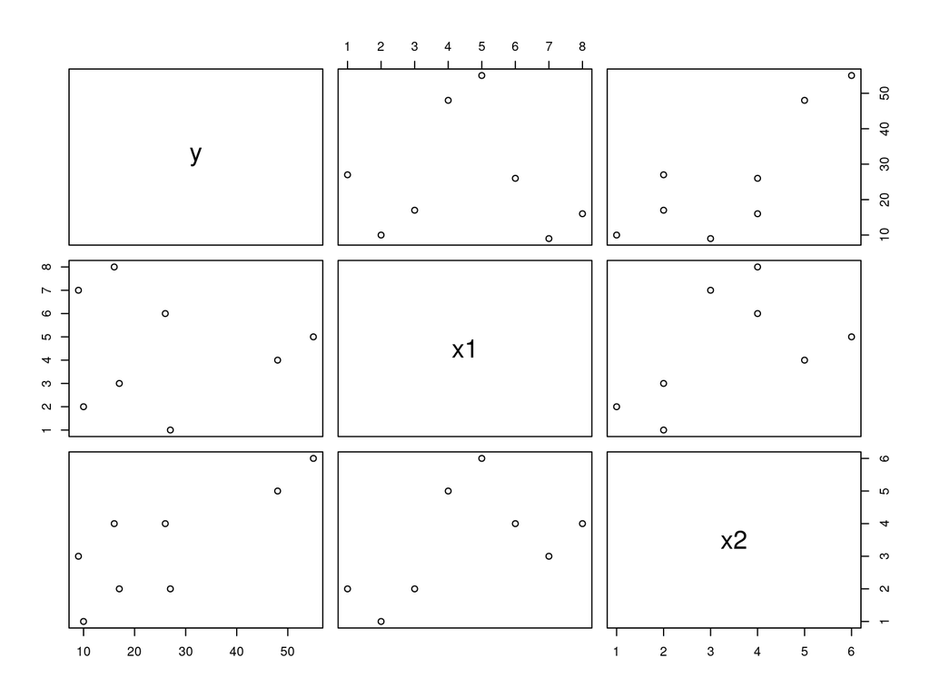

```r
x1 <- c(2,3,4,1,5,6,7,8)
x2 <- c(1,2,5,2,6,4,3,4)
y <- 8 - 5*x1 + 12*x2 + .01*rnorm(n = length(x1))
pairs(data.frame(y,x1,x2))
```

# Maximum Likelihood Estimation

Writing
$$\mathbf{y} = \mathbf{X} \boldsymbol{\beta} + \boldsymbol{\epsilon}$$
is the same as
$$\mathbf{y} \sim \text{Normal}\left(\mathbf{X} \boldsymbol{\beta}, \sigma^2 \mathbf{I}_n \right)$$
is the same as
$$f(\mathbf{y} \mid \mathbf{X}, \boldsymbol{\beta}, \sigma^2) = (2\pi)^{-n/2}\det[\sigma^2 \mathbf{I}_n]^{-1/2}\exp\left[-\frac{1}{2 \sigma^2 }(\mathbf{y} - \mathbf{X} \boldsymbol{\beta})^{\intercal}(\mathbf{y} - \mathbf{X} \boldsymbol{\beta}) \right]$$

is the same as
$$f(\mathbf{y} \mid \mathbf{X}, \boldsymbol{\beta}, \sigma^2) = (2\pi \sigma^2)^{-n/2}\exp\left[-\frac{1}{2 \sigma^2 } \sum_{i=1}^n (y_i - [\beta_0 + \beta_1 x_{i1} + \cdots + \beta_k x_{ik}])^2 \right]$$

# MLE

The negative log of
$$f(\mathbf{y} \mid \mathbf{X}, \boldsymbol{\beta}, \sigma^2) = (2\pi)^{-n/2}\det[\sigma^2 \mathbf{I}_n]^{-1/2}\exp\left[-\frac{1}{2 \sigma^2 }(\mathbf{y} - \mathbf{X} \boldsymbol{\beta})^{\intercal}(\mathbf{y} - \mathbf{X} \boldsymbol{\beta}) \right]$$
is
$$- \log f(\mathbf{y} \mid \mathbf{X}, \boldsymbol{\beta}, \sigma^2) = \frac{n}{2}\log(2\pi) + \frac{n}{2}\log \sigma^2 + \frac{1}{2 \sigma^2 }(\mathbf{y} - \mathbf{X} \boldsymbol{\beta})^{\intercal}(\mathbf{y} - \mathbf{X} \boldsymbol{\beta})$$
When we take derivatives with respect to the coefficients, we get the same thing as our original loss!

The MLE estimator of $\sigma^2$ has a different denominator, though.

# Hypothesis Testing revisited

We want to test all coefficients (except the intercept) at once:
$$H_0 : \beta_1 = \beta_2 = \cdots = \beta_k = 0$$

Too many tests inflates type 1 error!

The *omnibus F-test* test statistic:

$$F_0 = \frac{ SS_R / df_R }{ SS_{Res}/df_{Res} } \sim F_{df_R, df_{Res}}$$

Exactly the same formula, but the degrees of freedom changes.

# Sums of squares

Find $F_0$…

```r
summary(mlr_model)
```

```
##
## Call:
## lm(formula = y ~ x + xsquared, data = my_df)
##
## Residuals:
##     Min      1Q  Median      3Q     Max
## -46.172 -31.730   0.934  21.017  58.935
##
## Coefficients:
##             Estimate Std. Error t value Pr(>|t|)
## (Intercept)   6.1039    10.3340   0.591    0.562
## x            -0.1384     1.1356  -0.122    0.904
## xsquared     -5.0683     0.2104 -24.091 3.79e-15 ***
## ---
## Signif. codes:  0 '***' 0.001 '**' 0.01 '*' 0.05 '.' 0.1 ' ' 1
##
## Residual standard error: 31.51 on 18 degrees of freedom
## Multiple R-squared:  0.9699, Adjusted R-squared:  0.9666
## F-statistic: 290.2 on 2 and 18 DF,  p-value: 2.017e-14
```

# Individual Coefficients

$$t_0 = \frac{\hat{\beta}_j - \beta_j }{\sqrt{ \hat{\sigma}^2 [(\mathbf{X}^{\intercal}\mathbf{X})^{-1}]_{jj}} } \sim t_{df_{Res}}$$

- Test Statistic for $H_0: \beta_j = 0$:
  $$t_0 = \frac{\hat{\beta}_j }{ \sqrt{\hat{\sigma}^2 [(\mathbf{X}^{\intercal}\mathbf{X})^{-1}]_{jj}} }$$
- $1-\alpha$ CI
  $$\hat{\beta}_j \pm t_{\alpha/2, df_{Res}} \sqrt{\hat{\sigma}^2 [(\mathbf{X}^{\intercal}\mathbf{X})^{-1}]_{jj}}$$

# Individual T-tests

`summary()` does them all at once…

```r
summary(mlr_model)
```

```
##
## Call:
## lm(formula = y ~ x + xsquared, data = my_df)
##
## Residuals:
##     Min      1Q  Median      3Q     Max
## -46.172 -31.730   0.934  21.017  58.935
##
## Coefficients:
##             Estimate Std. Error t value Pr(>|t|)
## (Intercept)   6.1039    10.3340   0.591    0.562
## x            -0.1384     1.1356  -0.122    0.904
## xsquared     -5.0683     0.2104 -24.091 3.79e-15 ***
## ---
## Signif. codes:  0 '***' 0.001 '**' 0.01 '*' 0.05 '.' 0.1 ' ' 1
##
## Residual standard error: 31.51 on 18 degrees of freedom
## Multiple R-squared:  0.9699, Adjusted R-squared:  0.9666
## F-statistic: 290.2 on 2 and 18 DF,  p-value: 2.017e-14
```

# Sum of Squares decomposition

Before we talk about hypothesis tests for chunks of coefficients, let’s play around with the sums of squares…

Want to show:

$$SS_T = SS_R + SS_{Res}$$

first we should check

- $\mathbf{H}$ is *symmetric* (i.e. $\mathbf{H} = \mathbf{H}^{\intercal}$)
- $\mathbf{H}$ is *idempotent* (i.e. $\mathbf{H}^2 = \mathbf{H}$)
- $\mathbf{I} - \mathbf{H}$ is *symmetric* and *idempotent*
- $\frac{1}{n}\mathbf{1}\mathbf{1}^{\intercal}$ is *symmetric* and *idempotent*
- $\mathbf{H} \mathbf{X} = \mathbf{X}$

# Testing chunks of coefficients

Before we talk about hypothesis tests for chunks of coefficients, let’s play around with the sums of squares…

Check

$$SS_T = (\mathbf{y} - \frac{1}{n}\mathbf{1} \mathbf{1}^{\intercal}\mathbf{y} )^{\intercal}(\mathbf{y} - \frac{1}{n}\mathbf{1} \mathbf{1}^{\intercal}\mathbf{y} ) = \mathbf{y}^{\intercal}\left[\mathbf{I} - \frac{1}{n}\mathbf{1} \mathbf{1}^{\intercal} \right]\mathbf{y}$$

$$SS_{Res} = (\mathbf{y} - \mathbf{H}\mathbf{y} )^{\intercal}(\mathbf{y} - \mathbf{H}\mathbf{y} ) = \mathbf{y}^{\intercal}\left[\mathbf{I} - \mathbf{H} \right]\mathbf{y}$$

$$SS_{R} = (\mathbf{H}\mathbf{y} - \frac{1}{n}\mathbf{1} \mathbf{1}^{\intercal}\mathbf{y} )^{\intercal}(\mathbf{y} - \mathbf{H}\mathbf{y} ) = \mathbf{y}^{\intercal}\left[\mathbf{H} - \frac{1}{n}\mathbf{1}\mathbf{1}^{\intercal} \right]\mathbf{y}$$

$\mathbf{H}\mathbf{X} = \mathbf{X} \implies \mathbf{H}\mathbf{1} = \mathbf{1}$

# Sums of squares

Finally
$$\begin{align*}
SS_T &= (\mathbf{y} - \frac{1}{n}\mathbf{1} \mathbf{1}^{\intercal}\mathbf{y} )^{\intercal}(\mathbf{y} - \frac{1}{n}\mathbf{1} \mathbf{1}^{\intercal}\mathbf{y} ) \\
&= [(\mathbf{y} - \mathbf{H}\mathbf{y}) + (\mathbf{H}\mathbf{y} - \frac{1}{n}\mathbf{1} \mathbf{1}^{\intercal}\mathbf{y} )]^{\intercal} [(\mathbf{y} - \mathbf{H}\mathbf{y}) + (\mathbf{H}\mathbf{y} - \frac{1}{n} \mathbf{1} \mathbf{1}^{\intercal}\mathbf{y} )] \\
&= SS_R + SS_{Res} + 2(\mathbf{y} - \mathbf{H}\mathbf{y})^{\intercal}(\mathbf{H}\mathbf{y} - \frac{1}{n}\mathbf{1} \mathbf{1}^{\intercal}\mathbf{y} )\\
&= SS_R + SS_{Res} + 2(\mathbf{y} - \mathbf{H}\mathbf{y})^{\intercal}\mathbf{H}\mathbf{y} - \frac{2}{n}(\mathbf{y} - \mathbf{H}\mathbf{y})^{\intercal} \mathbf{1} \mathbf{1}^{\intercal}\mathbf{y} \\
&= SS_R + SS_{Res}
\end{align*}$$
because of the normal equations again
$$(\mathbf{y} - \mathbf{H}\mathbf{y})^{\intercal}\mathbf{H}\mathbf{y} = \underbrace{(\mathbf{y} - \mathbf{X}\hat{\boldsymbol{\beta}})^{\intercal}\mathbf{X}}_{0}(\mathbf{X}^{\intercal}\mathbf{X})^{-1}\mathbf{X}^{\intercal} \mathbf{y}$$
and

$$\underbrace{(\mathbf{y} - \mathbf{H}\mathbf{y})^{\intercal}\mathbf{1}}_{0} \mathbf{1}^{\intercal}\mathbf{y}$$

# Using `R`

Find $SS_R, SS_T, SS_{Res}$:

```r
anova(mlr_model)
```

```
## Analysis of Variance Table
##
## Response: y
##           Df Sum Sq Mean Sq  F value    Pr(>F)
## x          1     15      15   0.0149    0.9043
## xsquared   1 576253  576253 580.3548 3.794e-15 ***
## Residuals 18  17873     993
## ---
## Signif. codes:  0 '***' 0.001 '**' 0.01 '*' 0.05 '.' 0.1 ' ' 1
```

be careful…

# Testing chunks of coefficients

First, rewrite

$$\mathbf{y} = \mathbf{X} \boldsymbol{\beta} + \boldsymbol{\epsilon}$$

as

$$\mathbf{y}
=
\begin{bmatrix}
\mathbf{X}_{1} & \mathbf{X}_{2}
\end{bmatrix}
\begin{bmatrix}
\boldsymbol{\beta}_1 \\
\boldsymbol{\beta}_2
\end{bmatrix}
+
\boldsymbol{\epsilon}
= \mathbf{X}_1 \boldsymbol{\beta}_1 + \mathbf{X}_2 \boldsymbol{\beta}_2 + \boldsymbol{\epsilon}$$

We want to test $H_0: \boldsymbol{\beta}_2 = \mathbf{0}$

# Testing chunks of coefficients

For the *full model* $\mathbf{y} = \mathbf{X}_1 \boldsymbol{\beta}_1 + \mathbf{X}_2 \boldsymbol{\beta}_2 + \epsilon$

$$SS_{R}(\boldsymbol{\beta}) = \mathbf{y}^{\intercal}\left(\mathbf{H} - \frac{1}{n}\mathbf{1} \mathbf{1}^{\intercal}\right)\mathbf{y}$$

For the *reduced model* $\mathbf{y} = \mathbf{X}_1 \boldsymbol{\beta}_1 + \epsilon$

$$SS_{R}(\boldsymbol{\beta}_1) = \mathbf{y}^{\intercal}\left(\mathbf{H}_1 - \frac{1}{n}\mathbf{1} \mathbf{1}^{\intercal}\right)\mathbf{y}$$

where $\mathbf{H}_1 = \mathbf{X}_1 (\mathbf{X}_1^{\intercal}\mathbf{X}_1)^{-1}\mathbf{X}_1^{\intercal}$

- $SS_{R}(\boldsymbol{\beta}) - SS_{R}(\boldsymbol{\beta}_1)$ is the added *extra sum of squares*

So our test statistic is
$$F_0 = \frac{(SS_{R}(\boldsymbol{\beta})-SS_{R}(\boldsymbol{\beta}_1))/r }{MS_{Res}}$$
where $r$ is the number of elements of $\boldsymbol{\beta}_2$, and $MS_{Res}$ is from the full model.

# using `R`

```r
lil_mod <- lm(y ~ x, data = my_df)
big_mod <- lm(y ~ x + xsquared, data=my_df)
anova(lil_mod, big_mod) # smallest to largest
```

```
## Analysis of Variance Table
##
## Model 1: y ~ x
## Model 2: y ~ x + xsquared
##   Res.Df    RSS Df Sum of Sq      F    Pr(>F)
## 1     19 594126
## 2     18  17873  1    576253 580.35 3.794e-15 ***
## ---
## Signif. codes:  0 '***' 0.001 '**' 0.01 '*' 0.05 '.' 0.1 ' ' 1
```

```r
# by hand:
```

[output not shown]

# Adjusted $R^2$

Regular $R^2$ was
$$R^2 = 1 - \frac{SS_{Res}}{SS_T}$$

*Adjusted $R^2$* has a built-in penalty

$$R^2_{\text{adj}} = 1 - \frac{SS_{Res}/(n-k-1)}{SS_T/(n-1)}$$

`summary()` spits this out

# Prediction Intervals and CIs for mean responses

Need the distribution of $\hat{y}_0 = \mathbf{x}_0^{\intercal}\hat{\boldsymbol{\beta}}$…

Unbiasedness
$$E\left[ \mathbf{x}_0^{\intercal}\hat{\boldsymbol{\beta}} \right] = \mathbf{x}_0^{\intercal}E\left[ \hat{\boldsymbol{\beta}} \right] = \mathbf{x}_0^{\intercal}\boldsymbol{\beta}$$

Variance:
$$V[\hat{y}_0] = V[\mathbf{x}_0^{\intercal}\hat{\boldsymbol{\beta}}] =\sigma^2 \mathbf{x}_0^{\intercal}(\mathbf{X}^{\intercal}\mathbf{X})^{-1}\mathbf{x}_0$$

Prediction error variance:
$$V[y_0 - \hat{y}_0] = V[y_0] + V[\hat{y}_0]$$

# Prediction Intervals and CIs for mean responses

So
$$\hat{y}_0 = \mathbf{x}_0^{\intercal}\hat{\boldsymbol{\beta}} \sim \text{Normal}\left(\mathbf{x}_0^{\intercal}\boldsymbol{\beta}, \sigma^2 \mathbf{x}_0^{\intercal}(\mathbf{X}^{\intercal}\mathbf{X})^{-1}\mathbf{x}_0 \right)$$

Confidence interval for the mean response:

$$\mathbf{x}_0^{\intercal}\hat{\boldsymbol{\beta}} \pm t_{\alpha/2,df_{Res}}\sqrt{ \hat{\sigma}^2 \mathbf{x}_0^{\intercal}(\mathbf{X}^{\intercal}\mathbf{X})^{-1}\mathbf{x}_0 }$$

Prediction interval:

$$\mathbf{x}_0^{\intercal}\hat{\boldsymbol{\beta}} \pm t_{\alpha/2,df_{Res}}\sqrt{ \hat{\sigma}^2\left(1 + \mathbf{x}_0^{\intercal}(\mathbf{X}^{\intercal}\mathbf{X})^{-1}\mathbf{x}_0 \right) }$$

# Prediction Intervals and CIs for mean responses

Same code as before

```r
x0 <- data.frame(x = 30, xsquared = 20) #named!
predict(mlr_model, newdata = x0, interval = "confidence")
```

```
##       fit       lwr      upr
## 1 -99.416 -172.8025 -26.0295
```

```r
predict(mlr_model, newdata = x0, interval = "prediction")
```

```
##       fit       lwr        upr
## 1 -99.416 -198.2505 -0.5815068
```